# Bayesian Inference

INFO 521 · Module 4 · Lecture B — The Conjugate Gaussian Posterior

Greg Chism

College of Information Science · University of Arizona

August 2026

## Learning outcomes

By the end of Lecture B you should be able to:

1. **Place a Gaussian prior on the weights** and state the conjugate posterior $\mathcal{N}(\mathbf{w} \mid \mathbf{m}_N, \mathbf{S}_N)$.
2. **Read the update formulas** — what shrinks, what dominates, and why $\mathbf{X}^{\!\top}\mathbf{X}$ appears *again*.
3. **Show ridge regression is MAP** with a Gaussian prior ($\lambda = \sigma^2/\tau^2$).
4. **Form the posterior predictive** and separate its two variance terms.

## From θ to w

Lecture A put a distribution on a *proportion*. Now put one on the **regression weights** of the Module-1 model:

$$\begin{aligned}
\text{prior:}\quad
p(\mathbf{w}) &= \mathcal{N}(\mathbf{w} \mid \mathbf{m}_0,\ \mathbf{S}_0) \\[6pt]
\text{likelihood:}\quad
p(\mathbf{y}\mid\mathbf{X},\mathbf{w},\sigma^2)
&= \prod_{n=1}^{N}\mathcal{N}\!\left(y_n \,\middle|\, \mathbf{w}^{\!\top}\mathbf{x}_n,\ \sigma^2\right)
\end{aligned}$$

- $\mathbf{m}_0$ — where belief starts (e.g., “SBP near 120, no age effect”).
- $\mathbf{S}_0$ — how *loosely* it starts (wide diagonal = weakly informative).
- $\sigma^2$ — treated as **known** today (use m3a’s $\hat{\sigma}^2$); it keeps the algebra conjugate.

## The conjugate Gaussian posterior

Gaussian prior × Gaussian likelihood → **Gaussian posterior**, in closed form:

$$p(\mathbf{w} \mid \mathcal{D}) = \mathcal{N}(\mathbf{w} \mid \mathbf{m}_N,\ \mathbf{S}_N)$$

$$\boxed{\;
\begin{aligned}
\mathbf{S}_N &= \left(\mathbf{S}_0^{-1} + \tfrac{1}{\sigma^2}\mathbf{X}^{\!\top}\mathbf{X}\right)^{-1} \\[6pt]
\mathbf{m}_N &= \mathbf{S}_N\left(\mathbf{S}_0^{-1}\mathbf{m}_0 + \tfrac{1}{\sigma^2}\mathbf{X}^{\!\top}\mathbf{y}\right)
\end{aligned}
\;}$$

**Part 1 ends exactly here.** The full pipeline — data → model → loss → likelihood → posterior — closes on this pair of formulas.

## Reading the formulas

Work in **precisions** (inverse covariances) and the update is addition again:

- $\mathbf{S}_N^{-1} = \mathbf{S}_0^{-1} + \tfrac{1}{\sigma^2}\mathbf{X}^{\!\top}\mathbf{X}$ — **precisions add**: prior information + data information.
- The data’s contribution $\tfrac{1}{\sigma^2}\mathbf{X}^{\!\top}\mathbf{X}$ is the **Fisher information** $\mathcal{I}$ from m3b — the same object, fourth appearance.
- $\mathbf{m}_N$ is a **precision-weighted blend** of $\mathbf{m}_0$ and the data — the vector version of m4a’s shrinkage identity.
- $N \to \infty$: the data term dominates, $\mathbf{m}_N \to \hat{\mathbf{w}}_{\text{MLE}}$, $\ \mathbf{S}_N \to \sigma^2(\mathbf{X}^{\!\top}\mathbf{X})^{-1} = \mathrm{Cov}[\hat{\mathbf{w}}]$.

## Watching the posterior contract

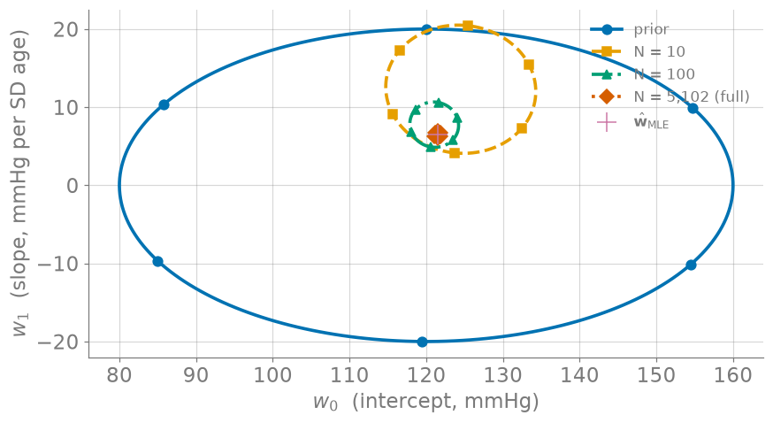

Figure 1: Conjugate posterior over (w₀, w₁), real NHANES draws (seed 521): prior → N = 10 → 100 → 5,102. The purple + is the MLE.

## Special case: the ridge prior

Take a **zero-mean isotropic** prior, $\ \mathbf{m}_0 = \mathbf{0}$, $\ \mathbf{S}_0 = \tau^2\mathbf{I}$:

$$\mathbf{m}_N
= \left(\mathbf{X}^{\!\top}\mathbf{X} + \tfrac{\sigma^2}{\tau^2}\,\mathbf{I}\right)^{-1}\mathbf{X}^{\!\top}\mathbf{y}
\;=\; \hat{\mathbf{w}}_{\text{ridge}}
\quad\text{with}\quad
\boxed{\;\lambda = \frac{\sigma^2}{\tau^2}\;}$$

- m2b’s forward hook, **cashed in**: the ridge penalty *is* a Gaussian prior.
- $\lambda$ stops being a dial and becomes a *statement*: noisy data (big $\sigma^2$) or a tight prior (small $\tau^2$) ⇒ shrink harder.

## MAP vs. the full posterior

The **MAP** (maximum a posteriori) estimate is the posterior’s peak:

$$\hat{\mathbf{w}}_{\text{MAP}}
= \arg\max_{\mathbf{w}}\ \bigl[\ell(\mathbf{w}) + \log p(\mathbf{w})\bigr]
\;=\; \mathbf{m}_N \quad (\text{Gaussian case: peak} = \text{mean}).$$

- **MAP is one number** — regularized fitting in Bayesian clothes; it discards the spread.
- **The posterior is the answer** — $\mathbf{S}_N$ carries what MAP throws away, and predictions (next slide) *use* it.
- Gaussians hide the difference (peak = mean); Module 5’s posteriors won’t be Gaussian, and the gap becomes the whole story.

## Predicting a new patient

For a new input $\mathbf{x}_\ast$, integrate the model over the posterior:

$$p(y_\ast \mid \mathbf{x}_\ast, \mathcal{D})
= \mathcal{N}\!\left(y_\ast \,\middle|\, \mathbf{m}_N^{\!\top}\mathbf{x}_\ast,\
\underbrace{\sigma^2}_{\text{noise}} + \underbrace{\mathbf{x}_\ast^{\!\top}\mathbf{S}_N\,\mathbf{x}_\ast}_{\text{parameter uncertainty}}\right)$$

Two variance terms, two different fixes:

- $\sigma^2$ — patient-level scatter; **irreducible** (m2b’s floor).
- $\mathbf{x}_\ast^{\!\top}\mathbf{S}_N\mathbf{x}_\ast$ — *our* ignorance of $\mathbf{w}$; **shrinks with data**, grows away from the data’s center.

## The predictive band on NHANES

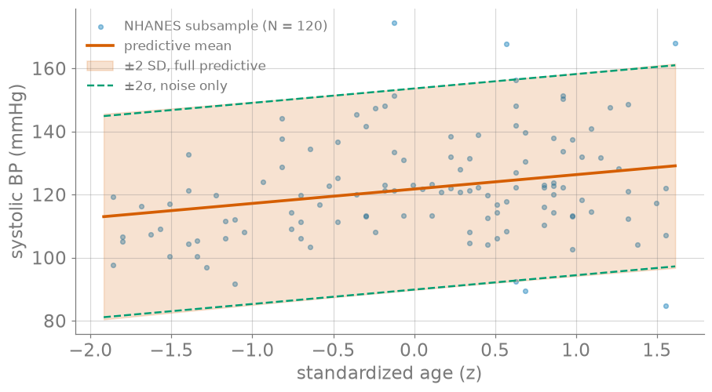

## The evidence, briefly

m4a’s ignored denominator, $p(\mathcal{D})$ — the **marginal likelihood** or *evidence* — is the likelihood **averaged over the prior**:

$$p(\mathcal{D}) = \int p(\mathcal{D} \mid \mathbf{w})\, p(\mathbf{w})\, d\mathbf{w}$$

- Scores a **whole model** (prior included), not one parameter value.
- Comparing evidences ranks models **without a test set** — an automatic Occam’s razor: too-flexible models spread their prior thin and score lower.
- For today’s conjugate model it, too, is closed-form; beyond, it is the first casualty (Module 5).

## Recap & bridge

- **Conjugate Gaussian posterior**: $\mathbf{S}_N^{-1} = \mathbf{S}_0^{-1} + \tfrac{1}{\sigma^2}\mathbf{X}^{\!\top}\mathbf{X}$, $\ \mathbf{m}_N = \mathbf{S}_N(\mathbf{S}_0^{-1}\mathbf{m}_0 + \tfrac{1}{\sigma^2}\mathbf{X}^{\!\top}\mathbf{y})$ — **Part 1’s endpoint**.
- **Ridge = MAP** with $\mathbf{S}_0 = \tau^2\mathbf{I}$: $\lambda = \sigma^2/\tau^2$.
- **Predictive variance** $= \sigma^2 + \mathbf{x}_\ast^{\!\top}\mathbf{S}_N\mathbf{x}_\ast$ — noise + ignorance, separately visible.

**Next (Module 5):** binarize the outcome — hypertensive or not — and the Gaussian likelihood is gone. Conjugacy **breaks**, no closed form survives, and approximation becomes the craft.